# Practical Machine Learning Project

Tingting He

12/08/2020

## Overview

The goal of this project is to predict the manner in which people do exercises. In other words, we predict the “classe” variable with other predictors. We first load the data and do some data cleansing steps. Then we train the models with four methods: random forest, boosting, LDA and Naive Bayes. It was found that random forest gives the highest prediction accuracy. We also combined random forest and boosting model then predict the testing data with them and explore the differences.

## Data Cleansing

The data was stored in two seperate documents: pml-training and plm-testing. We do the model training and validation with training data and we apply the best model on the testing data to predict the class. In this project, since there are many columns with very little information, we delete all the columns that have NA’s. The columns containing orders and timestamps are also removed since they are not informative as predictors. Thus, we have 56 variables left and we divide the data into training set (60%) and validation set (40%).

## Training Models

We first train four models with random forest, boosting, LDA and Naive Bayes seperately. The boosting method we use here is boosting with trees. Then we predict the “classe” variable in the validation set with these four models. The confusion matrices are displayed below.

```r
# Confusion matrices
confusionMatrix(predRF, crossv$classe)
```

```
## Confusion Matrix and Statistics
##
##           Reference
## Prediction    A    B    C    D    E
##          A 2230    7    0    0    0
##          B    1 1505    1    0    0
##          C    0    5 1367    3    0
##          D    0    1    0 1283    3
##          E    1    0    0    0 1439
##
## Overall Statistics
##
##                Accuracy : 0.9972
##                  95% CI : (0.9958, 0.9982)
##     No Information Rate : 0.2845
##     P-Value [Acc > NIR] : < 2.2e-16
##
##                   Kappa : 0.9965
##
##  Mcnemar's Test P-Value : NA
##
## Statistics by Class:
##
##                      Class: A Class: B Class: C Class: D Class: E
## Sensitivity            0.9991   0.9914   0.9993   0.9977   0.9979
## Specificity            0.9988   0.9997   0.9988   0.9994   0.9998
## Pos Pred Value         0.9969   0.9987   0.9942   0.9969   0.9993
## Neg Pred Value         0.9996   0.9979   0.9998   0.9995   0.9995
## Prevalence             0.2845   0.1935   0.1744   0.1639   0.1838
## Detection Rate         0.2842   0.1918   0.1742   0.1635   0.1834
## Detection Prevalence   0.2851   0.1921   0.1752   0.1640   0.1835
## Balanced Accuracy      0.9989   0.9956   0.9990   0.9985   0.9989
```

```r
confusionMatrix(predBT, crossv$classe)
```

```
## Confusion Matrix and Statistics
##
##           Reference
## Prediction    A    B    C    D    E
##          A 2223   23    0    1    0
##          B    7 1470   14    5   10
##          C    0   18 1349   11   11
##          D    2    7    3 1269   18
##          E    0    0    2    0 1403
##
## Overall Statistics
##
##                Accuracy : 0.9832
##                  95% CI : (0.9801, 0.9859)
##     No Information Rate : 0.2845
##     P-Value [Acc > NIR] : < 2.2e-16
##
##                   Kappa : 0.9787
##
##  Mcnemar's Test P-Value : NA
##
## Statistics by Class:
##
##                      Class: A Class: B Class: C Class: D Class: E
## Sensitivity            0.9960   0.9684   0.9861   0.9868   0.9730
## Specificity            0.9957   0.9943   0.9938   0.9954   0.9997
## Pos Pred Value         0.9893   0.9761   0.9712   0.9769   0.9986
## Neg Pred Value         0.9984   0.9924   0.9971   0.9974   0.9939
## Prevalence             0.2845   0.1935   0.1744   0.1639   0.1838
## Detection Rate         0.2833   0.1874   0.1719   0.1617   0.1788
## Detection Prevalence   0.2864   0.1919   0.1770   0.1656   0.1791
## Balanced Accuracy      0.9958   0.9813   0.9900   0.9911   0.9863
```

```r
confusionMatrix(predLDA, crossv$classe)
```

```
## Confusion Matrix and Statistics
##
##           Reference
## Prediction    A    B    C    D    E
##          A 1926  217  120   71   46
##          B   51  988  121   48  155
##          C  116  190  939  157   86
##          D  137   52  160  993  132
##          E    2   71   28   17 1023
##
## Overall Statistics
##
##                Accuracy : 0.748
##                  95% CI : (0.7383, 0.7576)
##     No Information Rate : 0.2845
##     P-Value [Acc > NIR] : < 2.2e-16
##
##                   Kappa : 0.6808
##
##  Mcnemar's Test P-Value : < 2.2e-16
##
## Statistics by Class:
##
##                      Class: A Class: B Class: C Class: D Class: E
## Sensitivity            0.8629   0.6509   0.6864   0.7722   0.7094
## Specificity            0.9191   0.9407   0.9153   0.9267   0.9816
## Pos Pred Value         0.8092   0.7249   0.6310   0.6737   0.8966
## Neg Pred Value         0.9440   0.9182   0.9325   0.9540   0.9375
## Prevalence             0.2845   0.1935   0.1744   0.1639   0.1838
## Detection Rate         0.2455   0.1259   0.1197   0.1266   0.1304
## Detection Prevalence   0.3033   0.1737   0.1897   0.1879   0.1454
## Balanced Accuracy      0.8910   0.7958   0.8008   0.8494   0.8455
```

```r
confusionMatrix(predNB, crossv$classe)
```

```
## Confusion Matrix and Statistics
##
##           Reference
## Prediction    A    B    C    D    E
##          A 1737  135   69   80   47
##          B   91 1044   84    7  159
##          C  186  223 1178  250   67
##          D  211  110   37  898   48
##          E    7    6    0   51 1121
##
## Overall Statistics
##
##                Accuracy : 0.7619
##                  95% CI : (0.7523, 0.7713)
##     No Information Rate : 0.2845
##     P-Value [Acc > NIR] : < 2.2e-16
##
##                   Kappa : 0.7
##
##  Mcnemar's Test P-Value : < 2.2e-16
##
## Statistics by Class:
##
##                      Class: A Class: B Class: C Class: D Class: E
## Sensitivity            0.7782   0.6877   0.8611   0.6983   0.7774
## Specificity            0.9410   0.9461   0.8879   0.9381   0.9900
## Pos Pred Value         0.8399   0.7538   0.6187   0.6887   0.9460
## Neg Pred Value         0.9143   0.9266   0.9680   0.9407   0.9518
## Prevalence             0.2845   0.1935   0.1744   0.1639   0.1838
## Detection Rate         0.2214   0.1331   0.1501   0.1145   0.1429
## Detection Prevalence   0.2636   0.1765   0.2427   0.1662   0.1510
## Balanced Accuracy      0.8596   0.8169   0.8745   0.8182   0.8837
```

As shown above, the accuray given by random forest is the highest, followed by boosting, which gives a slightly lower accuracy but still over 98%. The reason behind this could be that random forest applies boostrapping method, however processing random forest takes a rather long time compared with other methods.

To obtain a better interpretation of the predictors, a graph illustrating the importance of variables is displayed below. It is found that “num_window” takes up almost 100 importance which indicates it is vital for predicting class. Both “roll_belt” and “pitch_forearm” score high in importance as well.

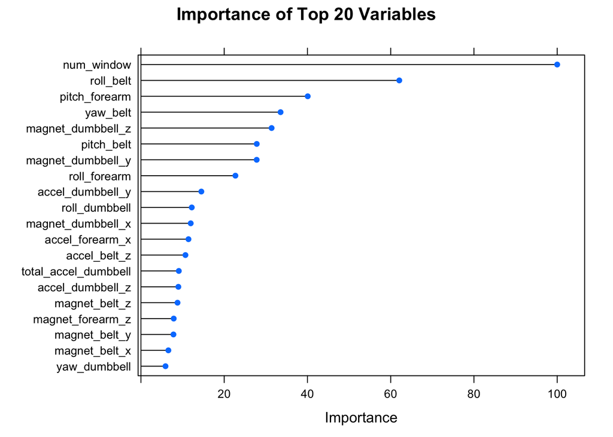

## Combining Models

```
## Confusion Matrix and Statistics
##
##           Reference
## Prediction    A    B    C    D    E
##          A 2230    7    0    0    0
##          B    1 1505    1    0    0
##          C    0    5 1367    3    0
##          D    0    1    0 1283    3
##          E    1    0    0    0 1439
##
## Overall Statistics
##
##                Accuracy : 0.9972
##                  95% CI : (0.9958, 0.9982)
##     No Information Rate : 0.2845
##     P-Value [Acc > NIR] : < 2.2e-16
##
##                   Kappa : 0.9965
##
##  Mcnemar's Test P-Value : NA
##
## Statistics by Class:
##
##                      Class: A Class: B Class: C Class: D Class: E
## Sensitivity            0.9991   0.9914   0.9993   0.9977   0.9979
## Specificity            0.9988   0.9997   0.9988   0.9994   0.9998
## Pos Pred Value         0.9969   0.9987   0.9942   0.9969   0.9993
## Neg Pred Value         0.9996   0.9979   0.9998   0.9995   0.9995
## Prevalence             0.2845   0.1935   0.1744   0.1639   0.1838
## Detection Rate         0.2842   0.1918   0.1742   0.1635   0.1834
## Detection Prevalence   0.2851   0.1921   0.1752   0.1640   0.1835
## Balanced Accuracy      0.9989   0.9956   0.9990   0.9985   0.9989
```

## Prediction

Since random forest, boosting and the combined model gives very similar accuracy, we will predict with three models seperately and check the difference:

```r
predRF <- predict(fitRF, testing)
predRF
```

```
##  [1] B A B A A E D B A A B C B A E E A B B B
## Levels: A B C D E
```

```r
predBT <- predict(fitBT, testing)
predBT
```

```
##  [1] B A B A A E D B A A B C B A E E A B B B
## Levels: A B C D E
```

```r
predTDF <- data.frame(predRF,predBT)
predict(combModFit, predTDF)
```

```
##  [1] B A B A A E D B A A B C B A E E A B B B
## Levels: A B C D E
```

The predictions provided by the models are the same. It is not surprising because all the three models give accuracies of over 98% in the validation above, which means they are very likely to give the “true” class. Besides, 20 observations is too small to tell any difference, we may see a different prediction with larger testing set.

Thus, the prediction of “classe” given by this project is B A B A A E D B A A B C B A E E A B B B.

## Reference

Ugulino, W.; Cardador, D.; Vega, K.; Velloso, E.; Milidiu, R.; Fuks, H. Wearable Computing: Accelerometers’ Data Classification of Body Postures and Movements. Proceedings of 21st Brazilian Symposium on Artificial Intelligence. Advances in Artificial Intelligence - SBIA 2012. In: Lecture Notes in Computer Science. , pp. 52-61. Curitiba, PR: Springer Berlin / Heidelberg, 2012. ISBN 978-3-642-34458-9. DOI: 10.1007/978-3-642-34459-6_6.

Read more: http://groupware.les.inf.puc-rio.br/har#ixzz6TfGaOBtD